# scFeatureFilter:

## correlation-based feature filtering for single-cell RNA-seq

### <span class="citation">@G_Devailly</span>

### 2018/01/17

# Introduction

- Single cell RNA-sequencing is increasingly popular.

- scRNA-seq is noisier than bulk RNA-seq.

- Filtering of noisy, lowly-expressed features.red[*] is common.

*Feature: gene or transcript

## Introduction

- Using spike-in RNA information

- Arbitrary filtering:

>.small[[...] on a filtered data set, where we retain only genes with an estimated
TPM above 1 in more than 25% of the considered cells.¹]

>.small[Genes with less than 5 reads and expressed in
less than 10 cells were removed.²]

>.small[Here, low-abundance genes are defined as those
with an average count below a filter threshold of 1 [count].³]

>.small[ Genes were filtered, keeping 15,633 out of 26,178 genes
that were expressed in at least 5 out of 1,919 sequenced cells (RPKM
≥ 10) and for which cells with expression came from at least
two different embryos.⁴]

.tiny[1 Soneson & Robinson, bioRxiv, 2017
2 Stevant et al., bioRxiv, 2017
3 Lun et al., F1000Research, 2016
4 Petropulos et al., Cell, 2016]

## Introduction

- No domain standard for filtering.

- Same Read count, FPKM, or TPM threshold might not be of the *same stringency*
in different datasets, notably across species.red[*].

* See Mansoki et al., Comput Biol Chem., 2016

* Can we do better?

# scFeatureFilter

- R package

- Available on GitHub:
[github.com/gdevailly/scFeatureFilte](https://github.com/gdevailly/scFeatureFilter)

- Accepted in [Bioconductor](https://www.bioconductor.org/packages/devel/bioc/html/scFeatureFilter.html)

Need R ≥ 3.5 (*or edit DESCRIPTION to depends: R ≥ 3.4*)

- Might help to set an relevant expression threshold for feature filtering.

```r
library(scFeatureFilter)
```

### Example datasets:

32 scRNA-seq of human embryonic stem cells (Yan et al., Nat Struct Mol Biol, 2013.)

```r
dim(scData_hESC)
## [1] 60468    33
```

```r
scData_hESC
```

|gene               | cell_1| cell_2| cell_3| cell_4|
|:------------------|------:|------:|------:|------:|
|ENSG00000000003.13 |  55.33|  35.98|  53.68|  31.95|
|ENSG00000000005.5  |   0.00|   0.00|   0.13|   0.00|
|ENSG00000000419.11 |  53.97|  55.47|  41.87| 110.75|
|ENSG00000000457.12 |   0.92|   0.22|   0.65|   0.87|
|ENSG00000000460.15 |   7.08|   1.35|   5.42|  16.61|
|ENSG00000000938.11 |   0.00|   0.00|   0.00|   0.00|

Expression matrices can  be either `data.frame`, `tibble`, `matrix` or `SingleCellExperiment`.

### Mean-variance exploration:

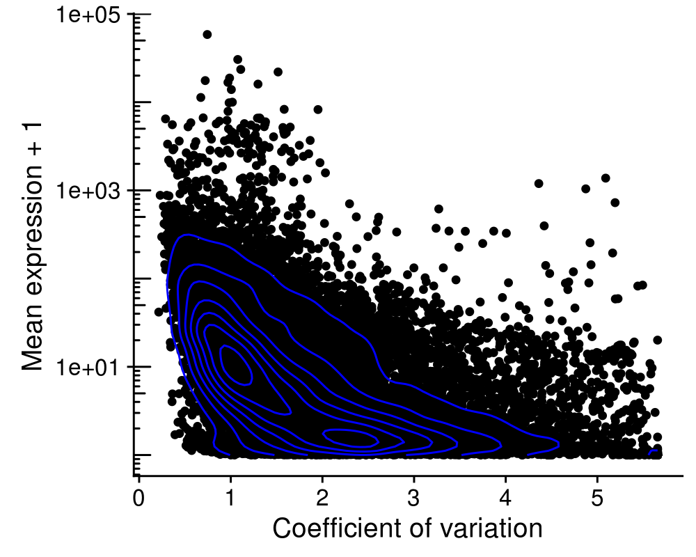

```r
calculate_cvs(scData_hESC, max_zeros = 0.75) %>%
    plot_mean_variance(colourByBin = FALSE) +
    annotation_logticks(sides = "l")
```

### Binning of the genes:

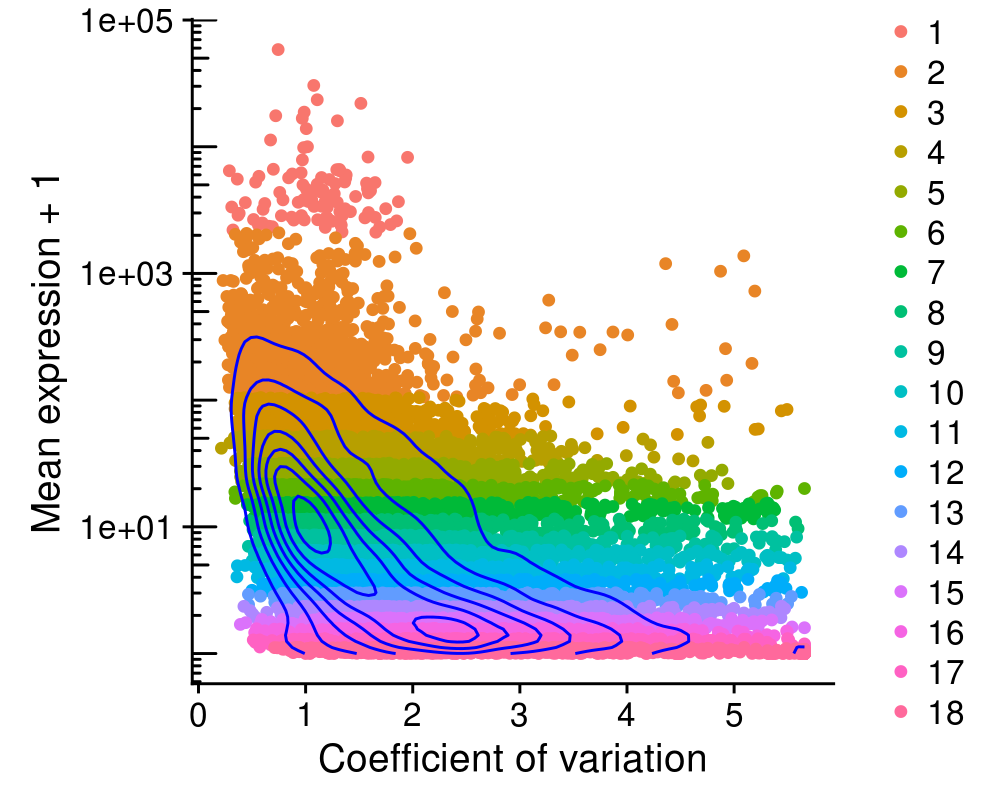

```r
scData_hESC %>%
    calculate_cvs %>%
    define_top_genes(window_size = 100) %>%
    bin_scdata(window_size = 1000) %>%
    plot_mean_variance() +
    annotation_logticks(sides = "l")
```

### Assumptions

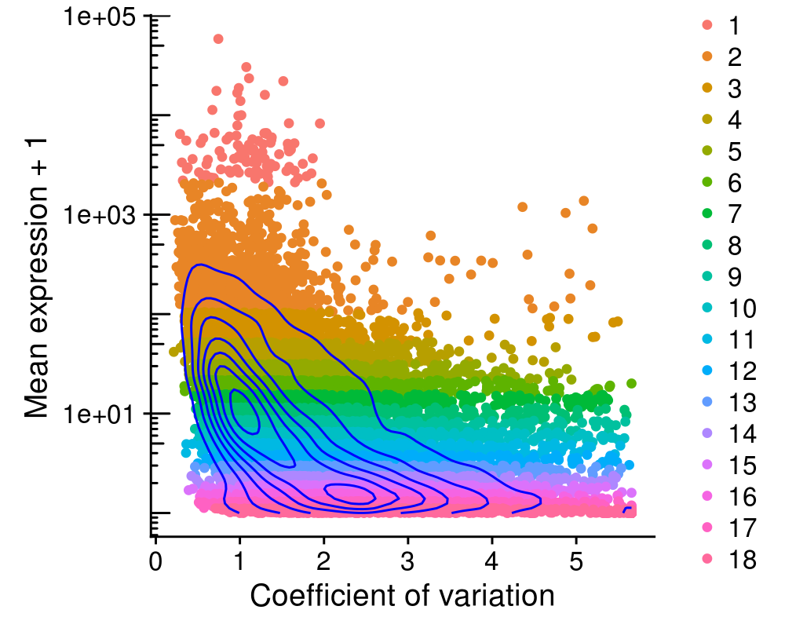

- high expression = less technical variation

- biological variation = transcription module

- correlation of genes belonging to the same transcription module

### Correlation of the data:

- **A reference set of genes**: the top bin

- Three control sets of genes: shuffling of the expression values of the reference set

Each gene in each bin is correlated against each gene in the **reference set**, and each gene in the 3 **control sets**:

```r
corDistrib <- scData_hESC %>%
    calculate_cvs %>%
    define_top_genes(window_size = 100) %>%
    bin_scdata(window_size = 1000) %>%
    correlate_windows(n_random = 3)
## Mean expression of last top gene: 2114.40221875
## Number of windows: 18
```

### Correlation of the data

```r
corDens <- correlations_to_densities(corDistrib)
plot_correlations_distributions(corDens, facet_ncol = 6) +
    scale_x_continuous(breaks = c(0, 0.5, 1), labels = c("0", "0.5", "1"))
```

[figure not shown]

### Correlation of the data

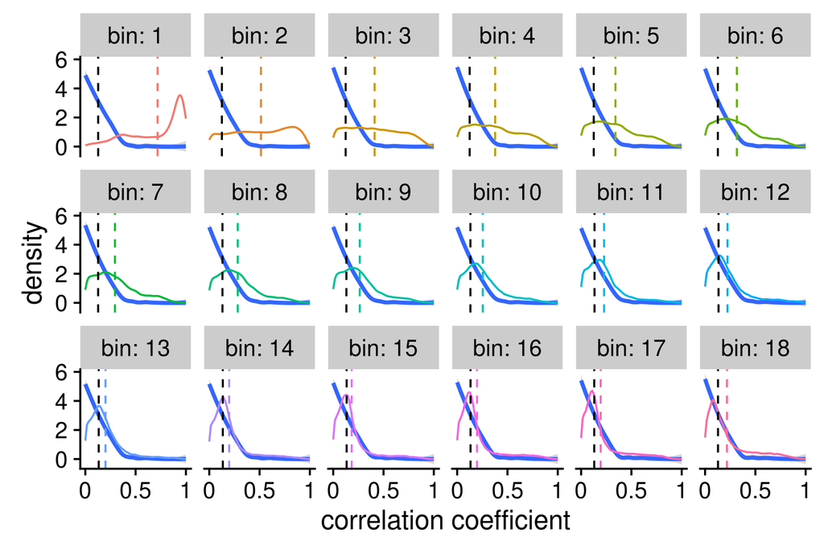

```r
metrics <- get_mean_median(corDistrib)
plot_correlations_distributions(corDens,  metrics = metrics, facet_ncol = 6) +
    scale_x_continuous(breaks = c(0, 0.5, 1), labels = c("0", "0.5", "1"))
```

### Threshold decision

[figure not shown]

```r
plot_metric(metrics, show_ctrl = FALSE, show_threshold = FALSE)
```